# Reproducable Research Peer-graded Assignment: Course Project 1

Sarfaraz Ahmed Qazi

12/12/2021

This assignment two months of data on human activities from an anonymous individual collected during the months of October and November, 2012. It include the number of steps taken in 5 minute intervals each day.

The dataset “Activity monitoring data (CSV format)” was downloaded from the course website link. The variables included in this dataset are:

steps: Number of steps taking in a 5-minute interval (missing values are coded as NA) date: The date on which the measurement was taken in YYYY-MM-DD format interval: Identifier for the 5-minute interval in which measurement was taken

Let us now solve the assignment questions one by one.

##Q.1 Code for reading in the dataset and/or processing the data

```r
library(ggplot2)
library(dplyr)
library(knitr)
library(Hmisc)
if (!file.exists("activity.csv") ) {
        unzip("activity.zip")
}

activity <- read.csv("activity.csv", header = TRUE)
activity$date <- as.POSIXct(activity$date, "%Y-%m-%d",tz="Asia/Urumqi" )
weekday <- weekdays(activity$date)
activity <- cbind(activity,weekday)
summary(activity)
```

```
##      steps             date               interval        weekday
##  Min.   :  0.00   Min.   :2012-10-01   Min.   :   0.0   Length:17568
##  1st Qu.:  0.00   1st Qu.:2012-10-16   1st Qu.: 588.8   Class :character
##  Median :  0.00   Median :2012-10-31   Median :1177.5   Mode  :character
##  Mean   : 37.38   Mean   :2012-10-31   Mean   :1177.5
##  3rd Qu.: 12.00   3rd Qu.:2012-11-15   3rd Qu.:1766.2
##  Max.   :806.00   Max.   :2012-11-30   Max.   :2355.0
##  NA's   :2304
```

## 2. Histogram of the total number of steps taken each day

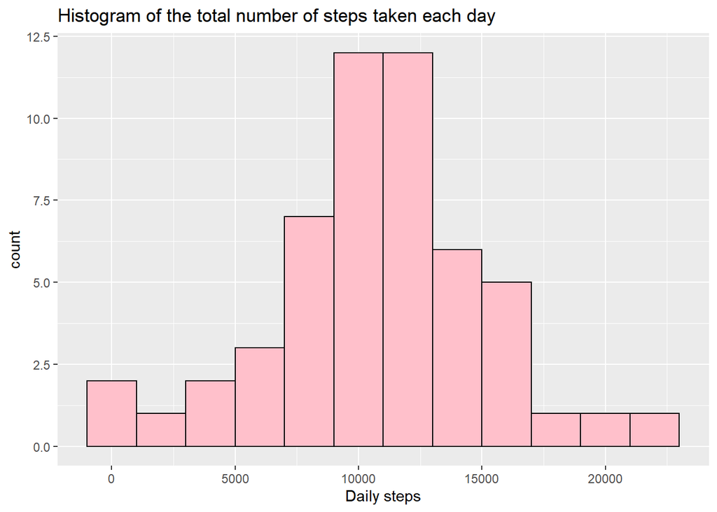

```r
ActivityDailySteps <- aggregate(steps~date, activity, sum)
ggplot(ActivityDailySteps, aes(steps)) +
  geom_histogram(fill = "pink", color = "black", binwidth = 2000) +
  labs(x = "Daily steps",
  title = "Histogram of the total number of steps taken each day")
```

##3. Mean and median number of steps taken each day

```r
DailyMeanSteps <- mean(ActivityDailySteps$steps, na.rm = TRUE)
DailyMedianSteps <- median(ActivityDailySteps$steps, na.rm = TRUE)
DailyMeanSteps
```

```
## [1] 10766.19
```

```r
DailyMedianSteps
```

```
## [1] 10765
```

##4. Time series plot of the average number of steps taken

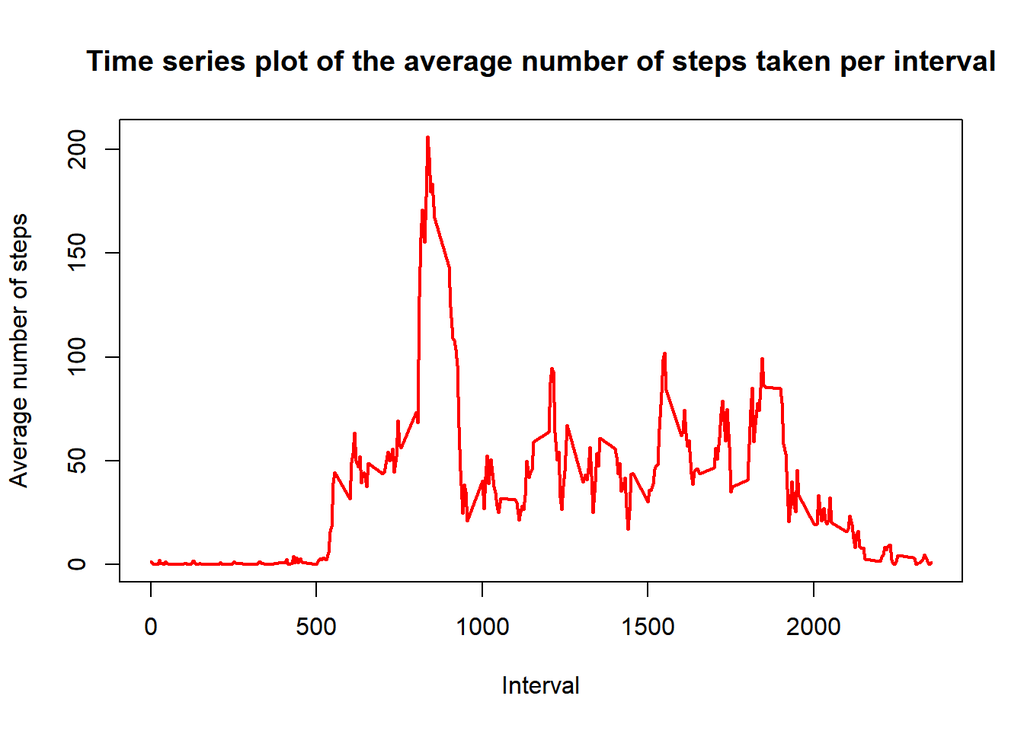

```r
DailyAverageActivity <- aggregate(activity$steps, by=list(activity$interval), FUN=mean, na.rm=TRUE)
names(DailyAverageActivity) <- c("interval", "mean")
plot(DailyAverageActivity$interval, DailyAverageActivity$mean, type = "l", col="red", lwd = 2, xlab="Interval", ylab="Average number of steps", main="Time series plot of the average number of steps taken per interval")
```

##5. The 5-minute interval that, on average, contains the maximum number of steps

```r
DailyAverageActivity[which.max(DailyAverageActivity$mean), ]$interval
```

```
## [1] 835
```

##6. Code to describe and show a strategy for imputing missing data

###6.1 Total number of rows with missing (NA) values in the dataset

```r
#sum(is.na(activity$steps))
TotalNAs <- length(which(is.na(activity$steps)))
TotalNAs
```

```
## [1] 2304
```

###6.2 Let us impute missing values/NA’s

```r
ImputedActivity <- activity
ImputedActivity$steps <- impute(activity$steps, fun=mean)
```

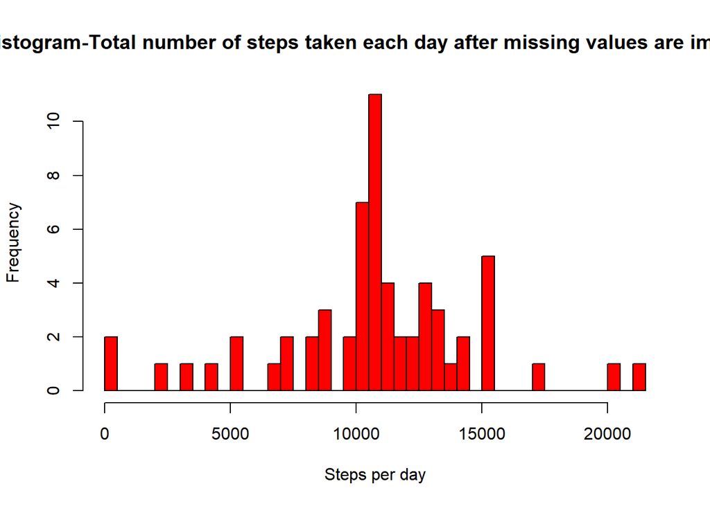

```r
Daily_StepsAfterImpute <- aggregate(ImputedActivity$steps,
                                by = list(Date = ImputedActivity$date),
                                FUN = "sum")
hist(Daily_StepsAfterImpute$x, col = "red",
     breaks = 50,
     main = "Histogram-Total number of steps taken each day after missing values are imputed",
     xlab = "Steps per day")
```

```r
ImputedActivity<- ImputedActivity%>%
        mutate(DayType= ifelse(weekdays(ImputedActivity$date)=="Saturday" | weekdays(ImputedActivity$date)=="Sunday", "Weekend", "Weekday"))
head(ImputedActivity)
```

```
##     steps       date interval weekday DayType
## 1 37.3826 2012-10-01        0  Monday Weekday
## 2 37.3826 2012-10-01        5  Monday Weekday
## 3 37.3826 2012-10-01       10  Monday Weekday
## 4 37.3826 2012-10-01       15  Monday Weekday
## 5 37.3826 2012-10-01       20  Monday Weekday
## 6 37.3826 2012-10-01       25  Monday Weekday
```

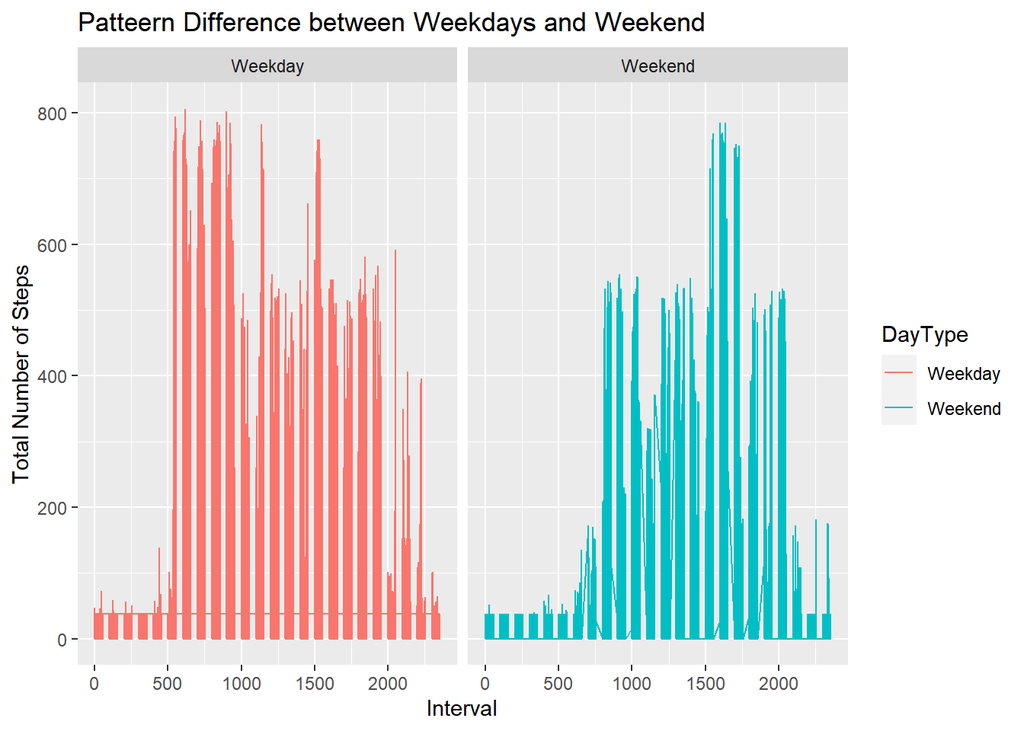

```r
ggplot(ImputedActivity, aes(x =interval , y=steps, color=DayType)) +
       geom_line() +
       labs(title = "Patteern Difference between Weekdays and Weekend", x = "Interval", y = "Total Number of Steps") +
       facet_wrap(~ DayType, ncol = 2, nrow=1)
```